# Relational Data (Completed Notebook)

R for Data Science

LDG

# Set-up

```r
library(tidyverse)
library(nycflights13) # for the section on relational data
```

## Acknowledgements

This notebook is based on Chapter 13 of of [*R for Data Science*](https://r4ds.had.co.nz/index.html).

# 1 The friendly skies

Here are all flights in and out of New York City in 2013 (more details [here](https://cran.r-project.org/web/packages/nycflights13/index.html)):

```r
flights
```

| year | month | day | dep_time | sched_dep_time | dep_delay | arr_time | sched_arr_time | arr_delay | carrier | flight | tailnum | origin | dest | air_time | distance | hour | minute | time_hour |
| --- | --- | --- | --- | --- | --- | --- | --- | --- | --- | --- | --- | --- | --- | --- | --- | --- | --- | --- |
| 2013 | 1 | 1 | 517 | 515 | 2 | 830 | 819 | 11 | UA | 1545 | N14228 | EWR | IAH | 227 | 1400 | 5 | 15 | 2013-01-01 05:00:00 |
| 2013 | 1 | 1 | 533 | 529 | 4 | 850 | 830 | 20 | UA | 1714 | N24211 | LGA | IAH | 227 | 1416 | 5 | 29 | 2013-01-01 05:00:00 |
| 2013 | 1 | 1 | 542 | 540 | 2 | 923 | 850 | 33 | AA | 1141 | N619AA | JFK | MIA | 160 | 1089 | 5 | 40 | 2013-01-01 05:00:00 |
| 2013 | 1 | 1 | 544 | 545 | -1 | 1004 | 1022 | -18 | B6 | 725 | N804JB | JFK | BQN | 183 | 1576 | 5 | 45 | 2013-01-01 05:00:00 |
| 2013 | 1 | 1 | 554 | 600 | -6 | 812 | 837 | -25 | DL | 461 | N668DN | LGA | ATL | 116 | 762 | 6 | 0 | 2013-01-01 06:00:00 |
| 2013 | 1 | 1 | 554 | 558 | -4 | 740 | 728 | 12 | UA | 1696 | N39463 | EWR | ORD | 150 | 719 | 5 | 58 | 2013-01-01 05:00:00 |
| 2013 | 1 | 1 | 555 | 600 | -5 | 913 | 854 | 19 | B6 | 507 | N516JB | EWR | FLL | 158 | 1065 | 6 | 0 | 2013-01-01 06:00:00 |
| 2013 | 1 | 1 | 557 | 600 | -3 | 709 | 723 | -14 | EV | 5708 | N829AS | LGA | IAD | 53 | 229 | 6 | 0 | 2013-01-01 06:00:00 |
| 2013 | 1 | 1 | 557 | 600 | -3 | 838 | 846 | -8 | B6 | 79 | N593JB | JFK | MCO | 140 | 944 | 6 | 0 | 2013-01-01 06:00:00 |
| 2013 | 1 | 1 | 558 | 600 | -2 | 753 | 745 | 8 | AA | 301 | N3ALAA | LGA | ORD | 138 | 733 | 6 | 0 | 2013-01-01 06:00:00 |

[output cut: 990 more lines]

The column `arr_delay` shows whether a flight landed early (negative) or late (positive). It has NAs:

```r
any(is.na(flights$arr_delay))
```

```
[1] TRUE
```

(`is.na(x)` returns a vector of length `x`, each element a `TRUE` or `FALSE`, but `any(is.na(x)`) returns a vector of length 1.)

Let’s filter out the NAs with `tidyr::drop_na` and plot the distribution

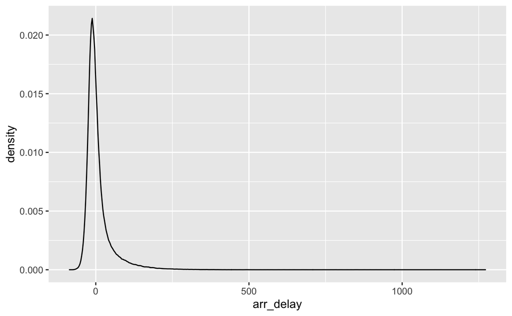

```r
flights %>%
  drop_na() %>%
  ggplot(., aes(x = arr_delay)) +
  geom_density()
```

Looks like on average flights arrive on time (who knew!). But we have lots of outliers. Let’s see if we can’t filter some out so we can run an analysis on the bulk of non-outlier observations. The logic is that processes that generate huge delays may be systematically different than processes generating small delays.

Use `stat_ecdf()` to plot the cumulative distribution:

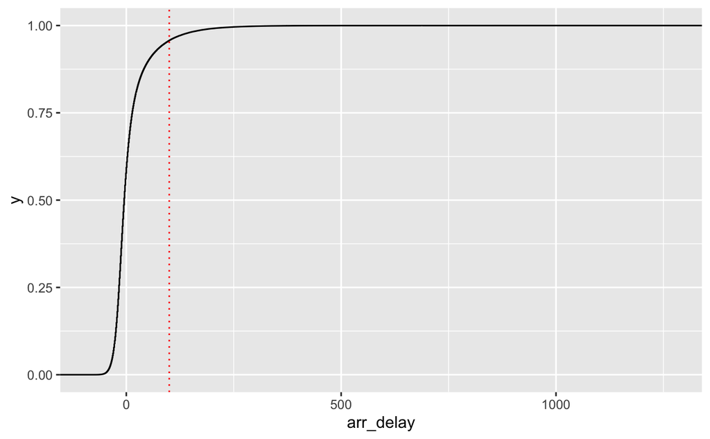

```r
flights %>%
  drop_na() %>%
  ggplot(., aes(x = arr_delay)) +
  stat_ecdf() +
  geom_vline(xintercept = 100, color = "red", linetype = "dotted")
```

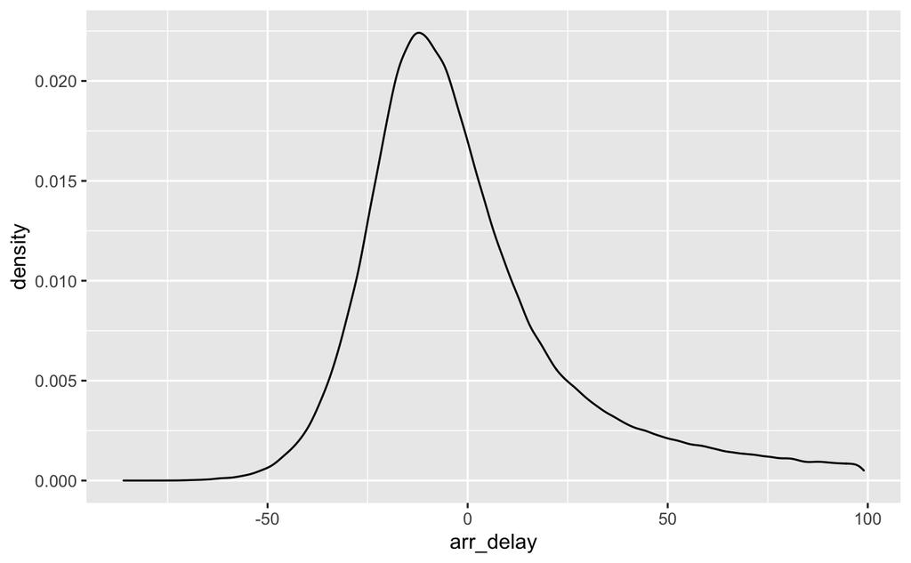

```r
flights %>%
  drop_na() %>%
  filter(arr_delay < 100) %>%
  ggplot(., aes(x = arr_delay)) +
  geom_density()
```

(Looks like average flights are actually early!!)

Side note: you can’t log-transform the data to smooth the outliers. Why? Because some arrivals are on time (`arr_delay == 0`) and others are early (`arr_delay < 0`). The problem is that `log(0)` is $-\infty$ while `log(-1)` (or any negative number) is undefined.

## 1.1 Modeling

What predicts late (or early) arrivals?

You could build a simple model of arrival delays as a function of certain variables, like weather, the operating airlines, the type of plane, and other variables plus some error:

$$\text{arrival delay} = f(\text{explanatory variables}) + \epsilon$$
and back estimate the parameters to explain the **conditional average delay** (the average delay conditional on your explanatory variables). If your model $f(\dots)$ is linear then you can just run OLS with `lm()`. And so on.

### 1.1.1 Where are my explanatory variables?

But while `flights` does have information about carriers in the column `carrier`:

```r
flights %>%
  drop_na() %>%
  filter(arr_delay < 100) %>%
  group_by(carrier) %>%
  summarise(avg_delay = mean(arr_delay))
```

| carrier | avg_delay |
| --- | --- |
| 9E | -2.143470 |
| AA | -5.250413 |
| AS | -13.966667 |
| B6 | 2.333172 |
| DL | -4.289311 |
| EV | 5.316443 |
| F9 | 8.566667 |
| FL | 8.798922 |
| HA | -12.391691 |
| MQ | 4.328330 |

[output cut: 6 more lines]

we only have an abbreviation (we’d have to look up those values). More details are stored in `airlines`:

```r
airlines
```

| carrier | name |
| --- | --- |
| 9E | Endeavor Air Inc. |
| AA | American Airlines Inc. |
| AS | Alaska Airlines Inc. |
| B6 | JetBlue Airways |
| DL | Delta Air Lines Inc. |
| EV | ExpressJet Airlines Inc. |
| F9 | Frontier Airlines Inc. |
| FL | AirTran Airways Corporation |
| HA | Hawaiian Airlines Inc. |
| MQ | Envoy Air |

[output cut: 6 more lines]

More importantly `flights` has scant data on planes or weather.

Those data are stored in different objects:

```r
planes
```

| tailnum | year | type | manufacturer | model | engines | seats | speed | engine |
| --- | --- | --- | --- | --- | --- | --- | --- | --- |
| N10156 | 2004 | Fixed wing multi engine | EMBRAER | EMB-145XR | 2 | 55 | NA | Turbo-fan |
| N102UW | 1998 | Fixed wing multi engine | AIRBUS INDUSTRIE | A320-214 | 2 | 182 | NA | Turbo-fan |
| N103US | 1999 | Fixed wing multi engine | AIRBUS INDUSTRIE | A320-214 | 2 | 182 | NA | Turbo-fan |
| N104UW | 1999 | Fixed wing multi engine | AIRBUS INDUSTRIE | A320-214 | 2 | 182 | NA | Turbo-fan |
| N10575 | 2002 | Fixed wing multi engine | EMBRAER | EMB-145LR | 2 | 55 | NA | Turbo-fan |
| N105UW | 1999 | Fixed wing multi engine | AIRBUS INDUSTRIE | A320-214 | 2 | 182 | NA | Turbo-fan |
| N107US | 1999 | Fixed wing multi engine | AIRBUS INDUSTRIE | A320-214 | 2 | 182 | NA | Turbo-fan |
| N108UW | 1999 | Fixed wing multi engine | AIRBUS INDUSTRIE | A320-214 | 2 | 182 | NA | Turbo-fan |
| N109UW | 1999 | Fixed wing multi engine | AIRBUS INDUSTRIE | A320-214 | 2 | 182 | NA | Turbo-fan |
| N110UW | 1999 | Fixed wing multi engine | AIRBUS INDUSTRIE | A320-214 | 2 | 182 | NA | Turbo-fan |

[output cut: 990 more lines]

and

```r
weather
```

| origin | year | month | day | hour | temp | dewp | humid | wind_dir | wind_speed | wind_gust | precip | pressure | visib | time_hour |
| --- | --- | --- | --- | --- | --- | --- | --- | --- | --- | --- | --- | --- | --- | --- |
| EWR | 2013 | 1 | 1 | 1 | 39.02 | 26.06 | 59.37 | 270 | 10.35702 | NA | 0.00 | 1012.0 | 10.00 | 2013-01-01 01:00:00 |
| EWR | 2013 | 1 | 1 | 2 | 39.02 | 26.96 | 61.63 | 250 | 8.05546 | NA | 0.00 | 1012.3 | 10.00 | 2013-01-01 02:00:00 |
| EWR | 2013 | 1 | 1 | 3 | 39.02 | 28.04 | 64.43 | 240 | 11.50780 | NA | 0.00 | 1012.5 | 10.00 | 2013-01-01 03:00:00 |
| EWR | 2013 | 1 | 1 | 4 | 39.92 | 28.04 | 62.21 | 250 | 12.65858 | NA | 0.00 | 1012.2 | 10.00 | 2013-01-01 04:00:00 |
| EWR | 2013 | 1 | 1 | 5 | 39.02 | 28.04 | 64.43 | 260 | 12.65858 | NA | 0.00 | 1011.9 | 10.00 | 2013-01-01 05:00:00 |
| EWR | 2013 | 1 | 1 | 6 | 37.94 | 28.04 | 67.21 | 240 | 11.50780 | NA | 0.00 | 1012.4 | 10.00 | 2013-01-01 06:00:00 |
| EWR | 2013 | 1 | 1 | 7 | 39.02 | 28.04 | 64.43 | 240 | 14.96014 | NA | 0.00 | 1012.2 | 10.00 | 2013-01-01 07:00:00 |
| EWR | 2013 | 1 | 1 | 8 | 39.92 | 28.04 | 62.21 | 250 | 10.35702 | NA | 0.00 | 1012.2 | 10.00 | 2013-01-01 08:00:00 |
| EWR | 2013 | 1 | 1 | 9 | 39.92 | 28.04 | 62.21 | 260 | 14.96014 | NA | 0.00 | 1012.7 | 10.00 | 2013-01-01 09:00:00 |
| EWR | 2013 | 1 | 1 | 10 | 41.00 | 28.04 | 59.65 | 260 | 13.80936 | NA | 0.00 | 1012.4 | 10.00 | 2013-01-01 10:00:00 |

[output cut: 990 more lines]

Can we join these data sets? Yes. But it’s not as simple as just binding columns together. Each data set has a different number of rows:

```r
nrow(flights)
```

```
[1] 336776
```

```r
nrow(airlines)
```

```
[1] 16
```

```r
nrow(planes)
```

```
[1] 3322
```

```r
nrow(weather)
```

```
[1] 26115
```

## 1.2 Merging data

The challenge is to **join** these data sets. The key to solving this problem is literally that: the **key** of each data set.

Data sets can have **keys** the uniquely idenfity observations. This builds on the idea of “tidy” data: each row a unique observation.

For instance, `tailnum` in `planes` uniquely identifies each plane. We can see this counting the number of repeats:

```r
planes %>%
  count(tailnum) %>%
  filter(n > 1)
```

| tailnum | n |
| --- | --- |

and finding none.

But `tailnum` does not uniquely identify observations in `flights`:

```r
flights %>%
  count(tailnum) %>%
  filter(n > 1)
```

| tailnum | n |
| --- | --- |
| D942DN | 4 |
| N0EGMQ | 371 |
| N10156 | 153 |
| N102UW | 48 |
| N103US | 46 |
| N104UW | 47 |
| N10575 | 289 |
| N105UW | 45 |
| N107US | 41 |
| N108UW | 60 |

[output cut: 990 more lines]

Because the same plane does many flights over the course of a year.

But `tailnum` in `flights` maps onto `tailnum` in `planes`.

and we use the **relationships** or mappings between data sets to join them (hence “relational data”).

Joins can get really [complicated](https://r4ds.had.co.nz/relational-data.html#join-problems). We will just focus on one type of join: an **outer join**.

## 1.3 Outer joins

In an outer join you keep all observations in one data set and add what you need from another.

`left_join` is the most common. If you have two data sets `x` and `y`, then:

```r
left_join(x,y, by = "key")
```

or

```r
x %>%
  left_join(y, by = "key")
```

says “keep all the data in `x`, and tack on the matching observations in `y`”. Matchings are identified by “key”. Using the pipe (`%>%`) makes it easier to do many joins.

Left joins are also the easiest to think about (in my opinion).

First, identify your “primary” data. In our case it’s `flights`.

Then, let the “non-primary” data “join in”.

## 1.4 Checkpoint

Let’s join `flights` with `planes` using `left_join`. The key again is `tailnum`.

```r
flights_planes <- flights %>%
  left_join(planes, by = "tailnum")

flights_planes
```

| year.x | month | day | dep_time | sched_dep_time | dep_delay | arr_time | sched_arr_time | arr_delay | carrier | flight | tailnum | origin | dest | air_time | distance | hour | minute | time_hour | year.y | type | manufacturer | model | engines | seats | speed | engine |
| --- | --- | --- | --- | --- | --- | --- | --- | --- | --- | --- | --- | --- | --- | --- | --- | --- | --- | --- | --- | --- | --- | --- | --- | --- | --- | --- |
| 2013 | 1 | 1 | 517 | 515 | 2 | 830 | 819 | 11 | UA | 1545 | N14228 | EWR | IAH | 227 | 1400 | 5 | 15 | 2013-01-01 05:00:00 | 1999 | Fixed wing multi engine | BOEING | 737-824 | 2 | 149 | NA | Turbo-fan |
| 2013 | 1 | 1 | 533 | 529 | 4 | 850 | 830 | 20 | UA | 1714 | N24211 | LGA | IAH | 227 | 1416 | 5 | 29 | 2013-01-01 05:00:00 | 1998 | Fixed wing multi engine | BOEING | 737-824 | 2 | 149 | NA | Turbo-fan |
| 2013 | 1 | 1 | 542 | 540 | 2 | 923 | 850 | 33 | AA | 1141 | N619AA | JFK | MIA | 160 | 1089 | 5 | 40 | 2013-01-01 05:00:00 | 1990 | Fixed wing multi engine | BOEING | 757-223 | 2 | 178 | NA | Turbo-fan |
| 2013 | 1 | 1 | 544 | 545 | -1 | 1004 | 1022 | -18 | B6 | 725 | N804JB | JFK | BQN | 183 | 1576 | 5 | 45 | 2013-01-01 05:00:00 | 2012 | Fixed wing multi engine | AIRBUS | A320-232 | 2 | 200 | NA | Turbo-fan |
| 2013 | 1 | 1 | 554 | 600 | -6 | 812 | 837 | -25 | DL | 461 | N668DN | LGA | ATL | 116 | 762 | 6 | 0 | 2013-01-01 06:00:00 | 1991 | Fixed wing multi engine | BOEING | 757-232 | 2 | 178 | NA | Turbo-fan |
| 2013 | 1 | 1 | 554 | 558 | -4 | 740 | 728 | 12 | UA | 1696 | N39463 | EWR | ORD | 150 | 719 | 5 | 58 | 2013-01-01 05:00:00 | 2012 | Fixed wing multi engine | BOEING | 737-924ER | 2 | 191 | NA | Turbo-fan |
| 2013 | 1 | 1 | 555 | 600 | -5 | 913 | 854 | 19 | B6 | 507 | N516JB | EWR | FLL | 158 | 1065 | 6 | 0 | 2013-01-01 06:00:00 | 2000 | Fixed wing multi engine | AIRBUS INDUSTRIE | A320-232 | 2 | 200 | NA | Turbo-fan |
| 2013 | 1 | 1 | 557 | 600 | -3 | 709 | 723 | -14 | EV | 5708 | N829AS | LGA | IAD | 53 | 229 | 6 | 0 | 2013-01-01 06:00:00 | 1998 | Fixed wing multi engine | CANADAIR | CL-600-2B19 | 2 | 55 | NA | Turbo-fan |
| 2013 | 1 | 1 | 557 | 600 | -3 | 838 | 846 | -8 | B6 | 79 | N593JB | JFK | MCO | 140 | 944 | 6 | 0 | 2013-01-01 06:00:00 | 2004 | Fixed wing multi engine | AIRBUS | A320-232 | 2 | 200 | NA | Turbo-fan |
| 2013 | 1 | 1 | 558 | 600 | -2 | 753 | 745 | 8 | AA | 301 | N3ALAA | LGA | ORD | 138 | 733 | 6 | 0 | 2013-01-01 06:00:00 | NA | NA | NA | NA | NA | NA | NA | NA |

[output cut: 990 more lines]

now we have a new data set with the same number of observations as `flights` – but with richer information about the type of plane used for each flight.

For instance, is there a relationship between the size of a plane (as measured by the number of engines) and delay time?

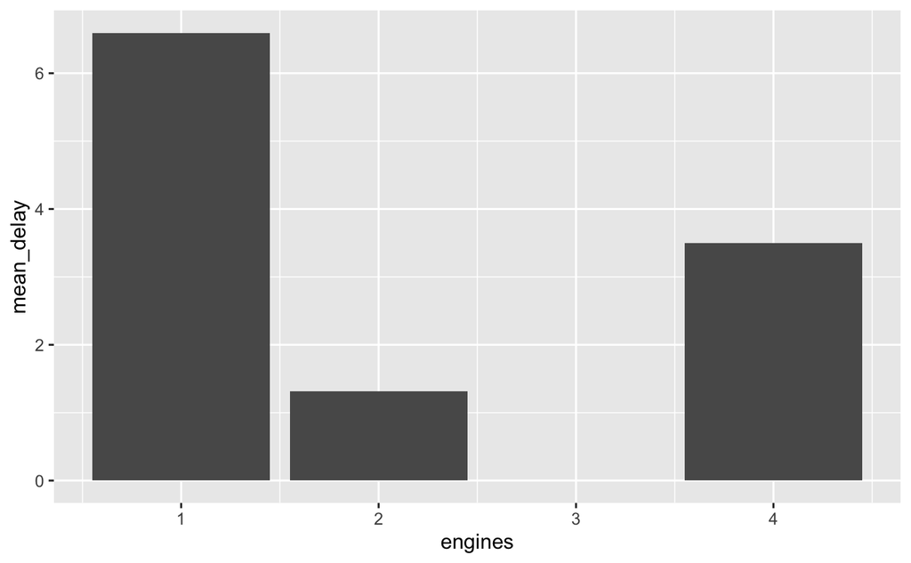

```r
flights_planes %>%
  drop_na() %>%
  group_by(engines) %>%
  summarise(mean_delay = mean(arr_delay)) %>%
  ggplot(data = ., aes(x = engines, y = mean_delay)) +
  geom_col()
```

## 1.5 Checkpoint

```r
flights_weather <- flights %>%
  left_join(weather, by = c("year", "month", "day", "hour", "origin"))
```

Is there a relationship between temperature (`temp`) and delay time (`arr_delay`)?

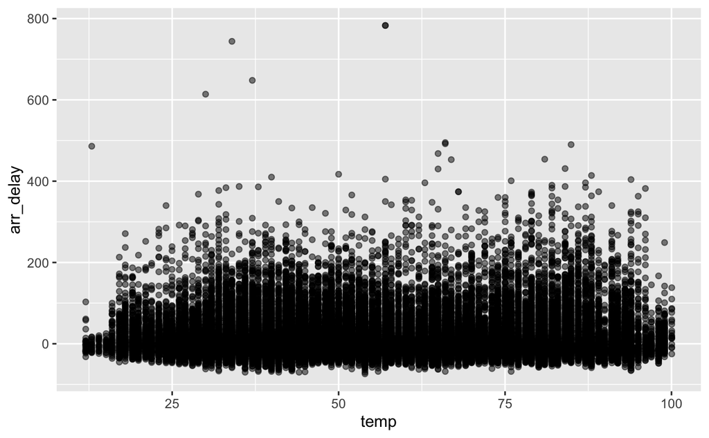

```r
flights_weather %>%
  drop_na() %>%
  ggplot(aes(x = temp, y = arr_delay)) +
  geom_point(alpha = 0.5)
```

## 1.6 Checkpoint

Join `flights`, `airlines`, `planes` and `weather`. Then test the hypothesis that JetBlue flights are significantly more delayed than American Airlines flights, others using a linear regression via `lm()`, controling for the temperature and the number of engines on a plane. The model is:

$$\begin{aligned}
\text{arrival delay} &= f(\text{airlines}, \text{temperature}, \text{engines}) + \epsilon \\
&= \beta_0 + \beta_1(\text{airlines}) + \beta_2(\text{temperature}) + \beta_3(\text{engines}) + \epsilon
\end{aligned}$$

First join the data (hint: join `weather` before `planes`):

```r
flights_enhanced <- flights %>%
  left_join(airlines, by = "carrier") %>%
  left_join(weather, by = c("year", "month", "day", "hour", "origin")) %>%
  left_join(planes, by = "tailnum")
```

Recall the airlines codes:

```r
airlines
```

| carrier | name |
| --- | --- |
| 9E | Endeavor Air Inc. |
| AA | American Airlines Inc. |
| AS | Alaska Airlines Inc. |
| B6 | JetBlue Airways |
| DL | Delta Air Lines Inc. |
| EV | ExpressJet Airlines Inc. |
| F9 | Frontier Airlines Inc. |
| FL | AirTran Airways Corporation |
| HA | Hawaiian Airlines Inc. |
| MQ | Envoy Air |

[output cut: 6 more lines]

Now filter and estimate the model:

```r
flights_enhanced %>%
  filter(carrier %in% c("AA", "B6")) %>%
  lm(formula = arr_delay ~ name + temp + engines, data = .) %>%
  summary()
```

```
Call:
lm(formula = arr_delay ~ name + temp + engines, data = .)

Residuals:
    Min      1Q  Median      3Q     Max
 -80.00  -23.86  -12.15    7.64 1006.07

Coefficients:
                     Estimate Std. Error t value Pr(>|t|)
(Intercept)         -3.023253   2.222248  -1.360    0.174
nameJetBlue Airways  9.266306   0.478394  19.370  < 2e-16 ***
temp                 0.070717   0.009884   7.155 8.46e-13 ***
engines             -0.389717   1.091463  -0.357    0.721
---
Signif. codes:  0 ‘***’ 0.001 ‘**’ 0.01 ‘*’ 0.05 ‘.’ 0.1 ‘ ’ 1

Residual standard error: 43.31 on 62780 degrees of freedom
  (24580 observations deleted due to missingness)
Multiple R-squared:  0.006687,  Adjusted R-squared:  0.006639
F-statistic: 140.9 on 3 and 62780 DF,  p-value: < 2.2e-16
```

Seems so!